# Games Sales

```r
library(tidyverse)
```

Explore the dataset

```r
games_sales <- CodeClanData::game_sales
head(games_sales)
```

| name | genre | year_of_release | publisher | sales | critic_score | user_score | developer | rating | platform |
| --- | --- | --- | --- | --- | --- | --- | --- | --- | --- |
| Wii Sports | Sports | 2006 | Nintendo | 82.53 | 76 | 8.0 | Nintendo | E | Wii |
| Mario Kart Wii | Racing | 2008 | Nintendo | 35.52 | 82 | 8.3 | Nintendo | E | Wii |
| Wii Sports Resort | Sports | 2009 | Nintendo | 32.77 | 80 | 8.0 | Nintendo | E | Wii |
| New Super Mario Bros. | Platform | 2006 | Nintendo | 29.80 | 89 | 8.5 | Nintendo | E | DS |
| Wii Play | Misc | 2006 | Nintendo | 28.92 | 58 | 6.6 | Nintendo | E | Wii |
| New Super Mario Bros. Wii | Platform | 2009 | Nintendo | 28.32 | 87 | 8.4 | Nintendo | E | Wii |

```r
NA
```

We want you to create an interactive visualisation(s) of this data using Shiny - use the tools learned through the lessons on ggplot and Shiny to create the visualisation, and it should have at least one iteractive element where the user can change the visualisation (for example via a widget).

It’s completely up to you which elements of the data you focus on. Please add a small comment with the code of each of your graphs/visuals to explain why you picked viewing the data in this way and what insight you hope the user will gain from it. This is great practice for the group project of starting to think about WHY you are plotting the data and thinking about what insights and decisions do you want the dashboard users to get from it.

Ideas for graphs: top 10 most-selling games ever, as a data table

```r
games_sales %>%
  arrange(desc(sales)) %>%
  head(n = 10)
```

| name | genre | year_of_release | publisher | sales | critic_score | user_score | developer | rating | platform |
| --- | --- | --- | --- | --- | --- | --- | --- | --- | --- |
| Wii Sports | Sports | 2006 | Nintendo | 82.53 | 76 | 8.0 | Nintendo | E | Wii |
| Mario Kart Wii | Racing | 2008 | Nintendo | 35.52 | 82 | 8.3 | Nintendo | E | Wii |
| Wii Sports Resort | Sports | 2009 | Nintendo | 32.77 | 80 | 8.0 | Nintendo | E | Wii |
| New Super Mario Bros. | Platform | 2006 | Nintendo | 29.80 | 89 | 8.5 | Nintendo | E | DS |
| Wii Play | Misc | 2006 | Nintendo | 28.92 | 58 | 6.6 | Nintendo | E | Wii |
| New Super Mario Bros. Wii | Platform | 2009 | Nintendo | 28.32 | 87 | 8.4 | Nintendo | E | Wii |
| Mario Kart DS | Racing | 2005 | Nintendo | 23.21 | 91 | 8.6 | Nintendo | E | DS |
| Wii Fit | Sports | 2007 | Nintendo | 22.70 | 80 | 7.7 | Nintendo | E | Wii |
| Wii Fit Plus | Sports | 2009 | Nintendo | 21.79 | 80 | 7.4 | Nintendo | E | Wii |
| Brain Age: Train Your Brain in Minutes a Day | Misc | 2005 | Nintendo | 20.15 | 77 | 7.9 | Nintendo | E | DS |

most-selling games per platform, as a data table

```r
games_sales %>%
  group_by(platform, sales) %>%
  slice(which.max(sales))
```

| name | genre | year_of_release | publisher | sales | critic_score | user_score | developer | rating | platform |
| --- | --- | --- | --- | --- | --- | --- | --- | --- | --- |
| Gravity Falls: Legend of the Gnome Gemulets | Action | 2015 | Ubisoft | 0.04 | 46 | 5.8 | Ubisoft | E | 3DS |
| Samurai Warriors Chronicles 3 | Action | 2014 | Tecmo Koei | 0.08 | 63 | 6.1 | Omega Force | T | 3DS |
| Brain Age: Concentration Training | Puzzle | 2012 | Nintendo | 0.09 | 71 | 7.9 | Nintendo | E | 3DS |
| James Noir's Hollywood Crimes | Adventure | 2011 | Ubisoft | 0.15 | 60 | 6.6 | Ubisoft | T | 3DS |
| F1 2011 | Racing | 2011 | Codemasters | 0.16 | 59 | 6.8 | Codemasters | E | 3DS |
| LEGO Marvel's Avengers | Action | 2016 | Warner Bros. Interactive Entertainment | 0.19 | 60 | 7.1 | TT Games | E10+ | 3DS |
| FIFA Soccer 13 | Action | 2012 | Electronic Arts | 0.29 | 68 | 3.7 | EA | E | 3DS |
| Tom Clancy's Splinter Cell 3D | Action | 2011 | Ubisoft | 0.30 | 53 | 5.5 | Ubisoft | T | 3DS |
| LEGO Legends of Chima: Laval's Journey | Adventure | 2013 | Warner Bros. Interactive Entertainment | 0.31 | 65 | 3.6 | TT Games | E10+ | 3DS |
| Tom Clancy's Ghost Recon: Shadow Wars | Strategy | 2011 | Ubisoft | 0.34 | 77 | 7.9 | Ubisoft | T | 3DS |

[output cut: 990 more lines]

revenue growth per genre over time

```r
games_sales %>%
  group_by(genre) %>%
  arrange(genre) %>%
  summarise(sum = sum(sales))
```

| genre | sum |
| --- | --- |
| Action | 401.61 |
| Adventure | 25.93 |
| Fighting | 112.65 |
| Misc | 190.18 |
| Platform | 169.48 |
| Puzzle | 28.06 |
| Racing | 165.31 |
| Role-Playing | 30.12 |
| Shooter | 166.79 |
| Simulation | 94.66 |

[output cut: 2 more lines]

composition graph of revenue by genre on each platform, snapshot or over time

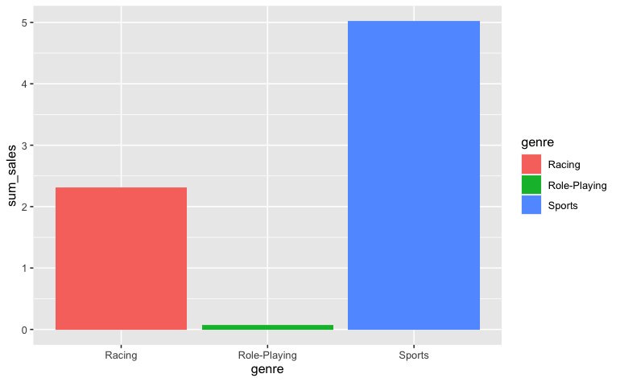

```r
games_sales %>%
  filter(year_of_release == 1999) %>%
  group_by(genre) %>%
  summarise(sum_sales = sum(sales)) %>%
  arrange((sum_sales)) %>%
  ggplot() +
  geom_bar(aes(x = genre, y = sum_sales, fill = genre), stat = "identity")
```

```r
NA
```

scatter plot of critic score and user score, perhaps for one platform, after transforming a user score

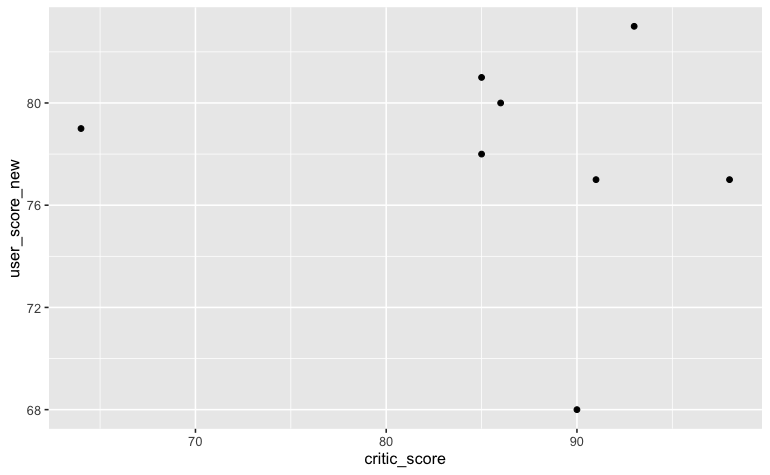